# HW5: Monte Carlo Simulation in R

Sokona Mangane

2023-02-15

# Portfolio Evalution

Implement a Monte Carlo simulation model for this portfolio using R. Experiment with various values for *N*. Experiment with various values for *T*, the terminal time in years. Generate some meaningful histograms, superimposing the sample mean as well as a sample variance statistic of your choice (e.g., 5th and 95th percentiles, or 25th and 75th percentiles — use `quantile`). What kind of decisions can you make based on your results?

## 1

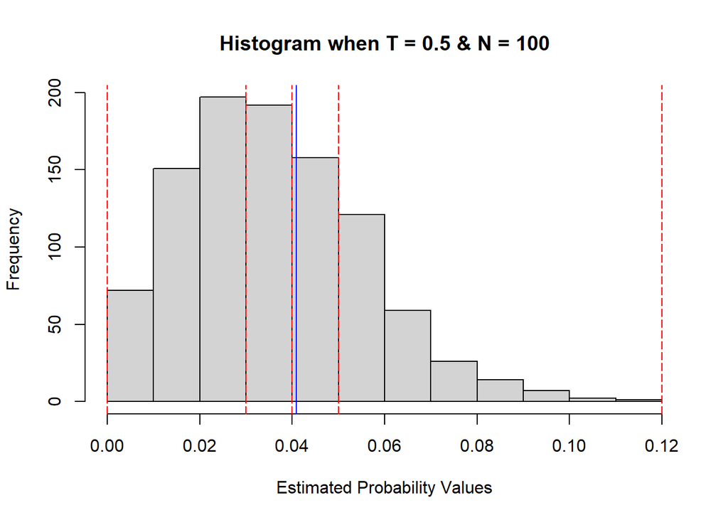

```r
prob <- list()
na = 100
nb = na
meana = 0.15
meanb = 0.12
sda = 0.20
sdb = 0.18
sa0 = 100
sb0 = 75


ms_stocks <- function(t, N){
  prob <- rep(0,N)
  for (i in 1:N){
    ba = rnorm (1, 0, sqrt(t))
    bb = rnorm(1, 0, sqrt(t))
    saT = sa0 * exp(((meana - ((sda^2)/2)) * t) + (sda * ba))
    sbT = sb0 * exp(((meanb - (((sdb)^2)/2)) * t) + (sdb * bb))
    condx = (((na * saT) + (nb * sbT))/ ((na * sa0) + (nb * sb0)))
      ifelse(condx <= 0.9, prob[i] <- 1, prob[i] <- 0)
    probl = sum(prob)/N
  }
  return(probl)
}

monte_hist <- rep(0,1000)

for (i in 1:1000){
  monte_hist[i] <- ms_stocks(0.5, 100)
}

hist(monte_hist, main = "Histogram when T = 0.5 & N = 100", xlab = "Estimated Probability Values")
m1 <- mean(monte_hist)
abline(v = m1, col = "blue")
c <- quantile(monte_hist)
abline(v = c, col = "red", lty = 5)
```

## 2

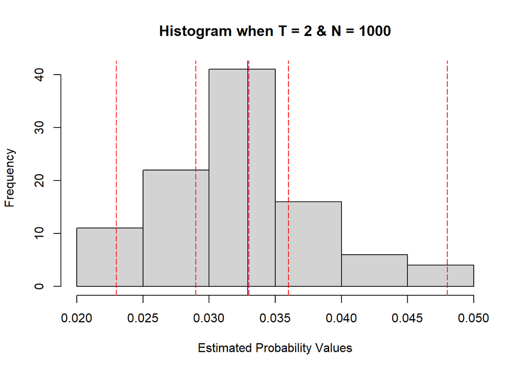

```r
t = seq(0,20, by = 2)
N = seq(1000,10000, by = 1000)


monte_hist1 <- rep(0,100)

for (i in 1:100){
  monte_hist1[i] <- ms_stocks(t[2], N[1])
}

hist(monte_hist1, main = "Histogram when T = 2 & N = 1000", xlab = "Estimated Probability Values")
m <- mean(monte_hist1)
abline(v = m, col = "blue")
c <- quantile(monte_hist1)
abline(v = c, col = "red", lty = 5)
```

## 3

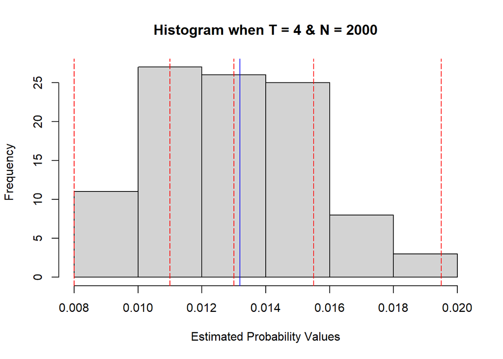

```r
monte_hist2 <- rep(0,100)

for (i in 1:100){
  monte_hist2[i] <- ms_stocks(t[3], N[2])
}

hist(monte_hist2, main = "Histogram when T = 4 & N = 2000", xlab = "Estimated Probability Values")
m <- mean(monte_hist2)
abline(v = m, col = "blue")
c <- quantile(monte_hist2)
abline(v = c, col = "red", lty = 5)
```

## 4

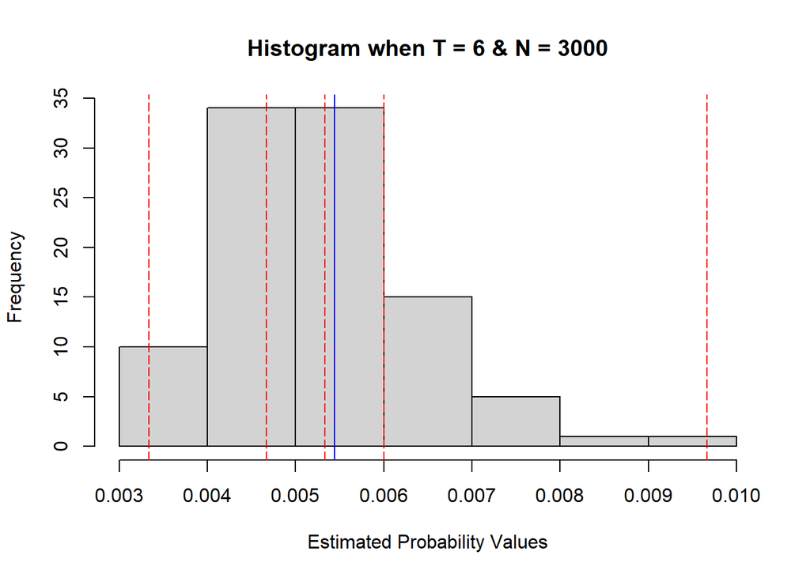

```r
monte_hist3 <- rep(0,100)

for (i in 1:100){
  monte_hist3[i] <- ms_stocks(t[4], N[3])
}

hist(monte_hist3, main = "Histogram when T = 6 & N = 3000", xlab = "Estimated Probability Values")
m <- mean(monte_hist3)
abline(v = m, col = "blue")
c <- quantile(monte_hist3)
abline(v = c, col = "red", lty = 5)
```

## 5

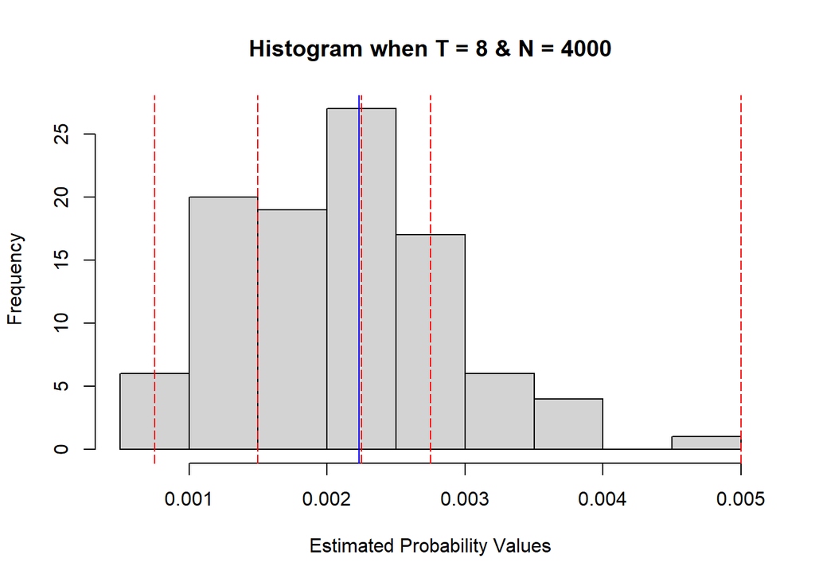

```r
monte_hist4 <- rep(0,100)

for (i in 1:100){
  monte_hist4[i] <- ms_stocks(t[5], N[4])
}

hist(monte_hist4, main = "Histogram when T = 8 & N = 4000", xlab = "Estimated Probability Values")
m <- mean(monte_hist4)
abline(v = m, col = "blue")
c <- quantile(monte_hist4)
abline(v = c, col = "red", lty = 5)
```

## 6

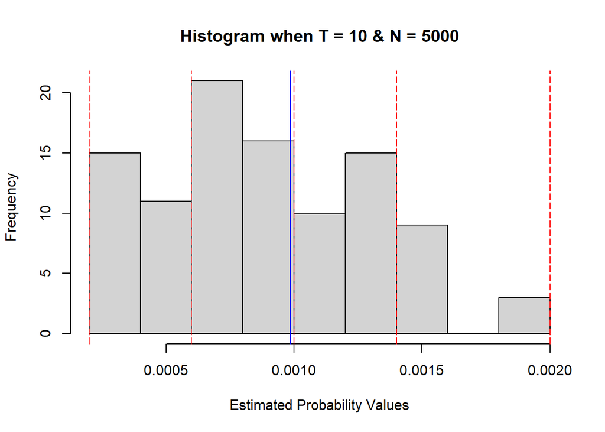

```r
monte_hist5 <- rep(0,100)

for (i in 1:100){
  monte_hist5[i] <- ms_stocks(t[6], N[5])
}

hist(monte_hist5, main = "Histogram when T = 10 & N = 5000", xlab = "Estimated Probability Values")
m <- mean(monte_hist5)
abline(v = m, col = "blue")
c <- quantile(monte_hist5)
abline(v = c, col = "red", lty = 5)
```

## 7

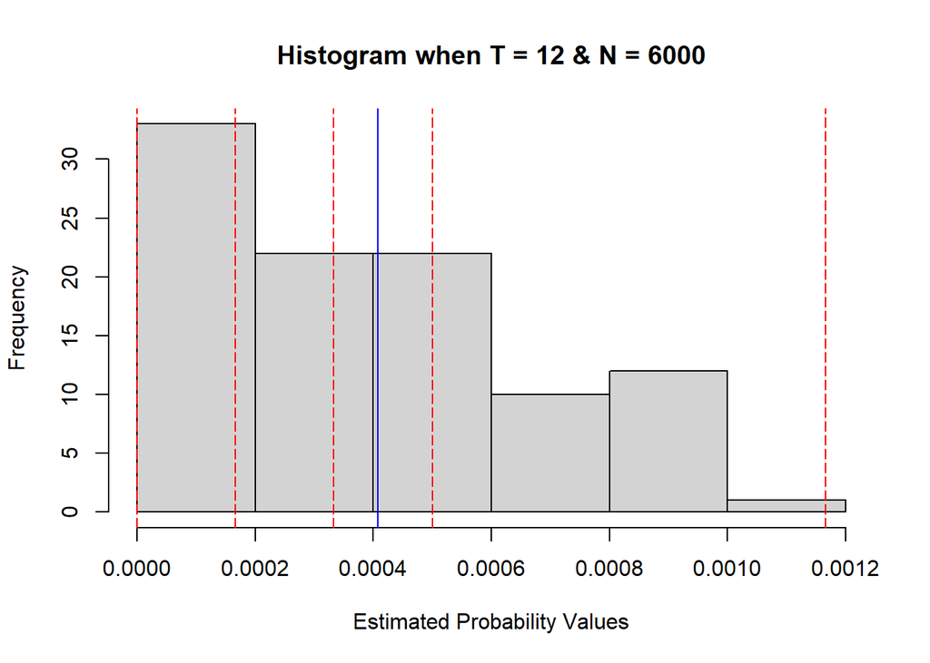

```r
monte_hist6 <- rep(0,100)

for (i in 1:100){
  monte_hist6[i] <- ms_stocks(t[7], N[6])
}

hist(monte_hist6, main = "Histogram when T = 12 & N = 6000", xlab = "Estimated Probability Values")
m <- mean(monte_hist6)
abline(v = m, col = "blue")
c <- quantile(monte_hist6)
abline(v = c, col = "red", lty = 5)
```

## 8

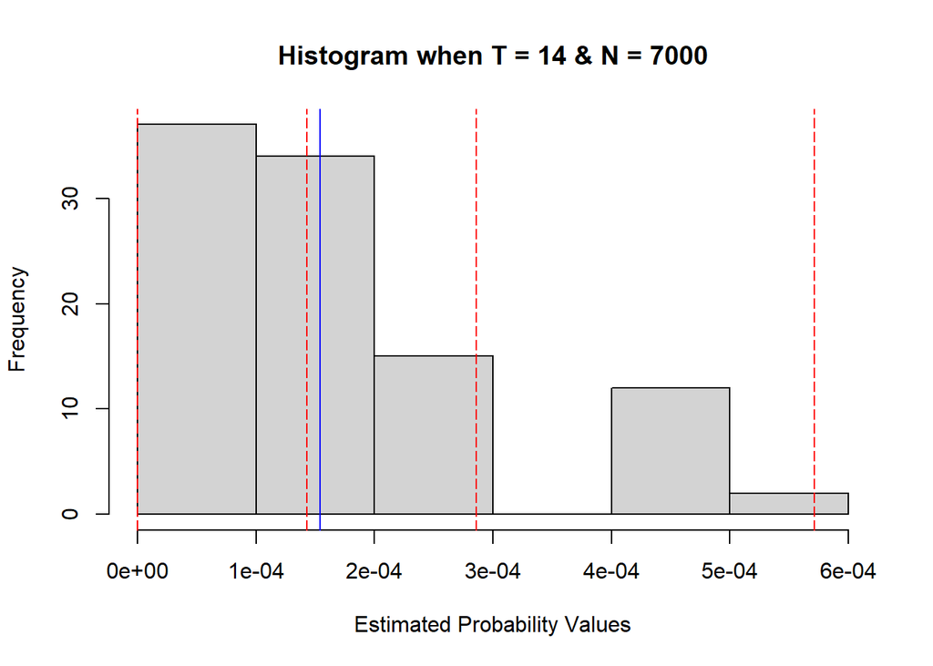

```r
monte_hist7 <- rep(0,100)

for (i in 1:100){
  monte_hist7[i] <- ms_stocks(t[8], N[7])
}

hist(monte_hist7, main = "Histogram when T = 14 & N = 7000", xlab = "Estimated Probability Values")
m <- mean(monte_hist7)
abline(v = m, col = "blue")
c <- quantile(monte_hist7)
abline(v = c, col = "red", lty = 5)
```

## 9

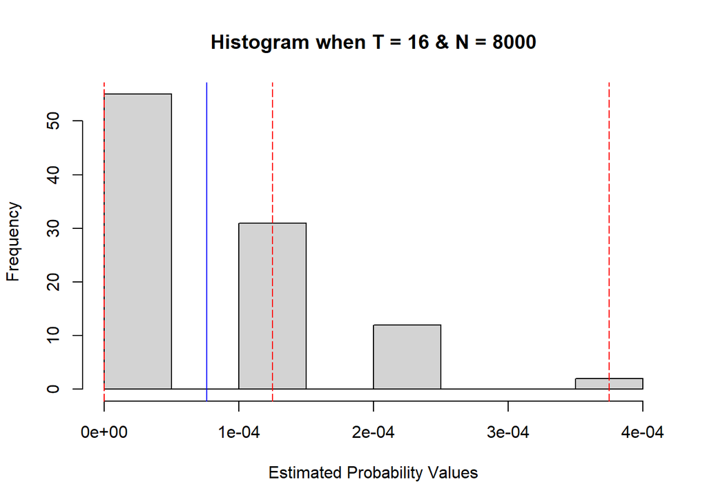

```r
monte_hist8 <- rep(0,100)

for (i in 1:100){
  monte_hist8[i] <- ms_stocks(t[9], N[8])
}

hist(monte_hist8, main = "Histogram when T = 16 & N = 8000", xlab = "Estimated Probability Values")
m <- mean(monte_hist8)
abline(v = m, col = "blue")
c <- quantile(monte_hist8)
abline(v = c, col = "red", lty = 5)
```

## 10

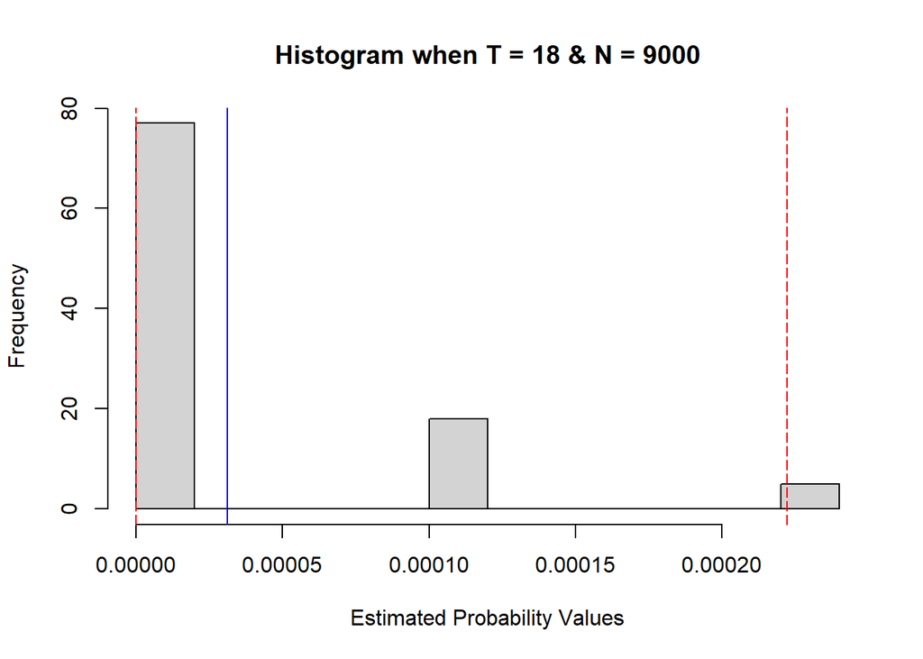

```r
monte_hist9 <- rep(0,100)

for (i in 1:100){
  monte_hist9[i] <- ms_stocks(t[10], N[9])
}

hist(monte_hist9, main = "Histogram when T = 18 & N = 9000", xlab = "Estimated Probability Values")
m <- mean(monte_hist9)
abline(v = m, col = "blue")
c <- quantile(monte_hist9)
abline(v = c, col = "red", lty = 5)
```

## 11

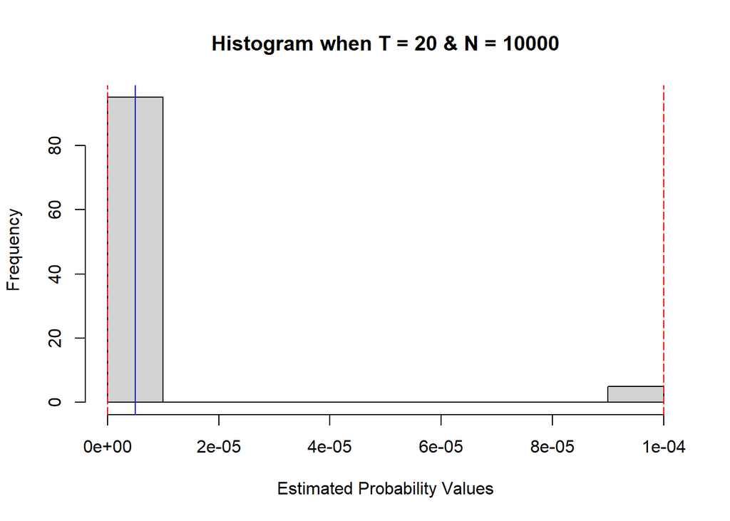

```r
monte_hist10 <- rep(0,100)

for (i in 1:100){
  monte_hist10[i] <- ms_stocks(t[11], N[10])
}

hist(monte_hist10, main = "Histogram when T = 20 & N = 10000", xlab = "Estimated Probability Values")
m <- mean(monte_hist10)
abline(v = m, col = "blue")
c <- quantile(monte_hist10)
abline(v = c, col = "red", lty = 5)
```

In terms of the shape of the graph, although our N did get larger, it didn’t make our distribution more “normal”. However, I think it’s because our values became extremely small, thus causing the graph to look skewed. These results show us that it would actually be beneficial to buy 100 shares of these two stocks. As we run more simulations and as time goes on, the probability that our portfolio will drop by more than 10% is almost 0. The mean changed from 0.04088 to 5^{-6}, therefore, the portfolio would increase in value over time.